# Individual differences

In **Pilot 1**, there are 27 subjects who did the curiosity personal trait questionaire. The following analysis will only include these subjects who had personal trait scores.

# 1 Relationship between trait score and slope of curiosity-memory relationship

## 1.1 Outside

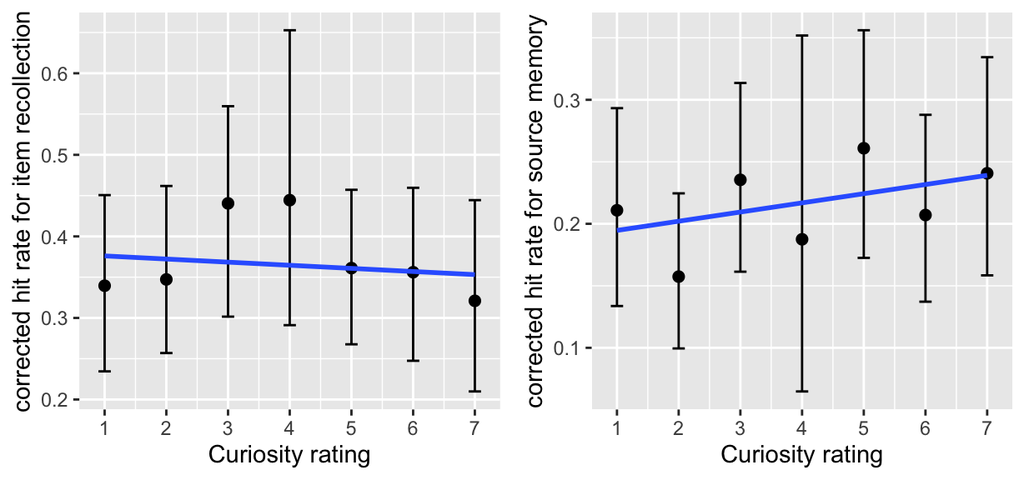

### 1.1.1 Item recollection

#### 1.1.1.1 Correlation with the average score

```
##                  Model df       AIC       BIC   logLik   Test   L.Ratio
## baseline.rating      1  3 -1.839940  6.472113 3.919970
## rating.intercept     2  4  0.159780 11.242518 3.920110 1 vs 2 0.0002801
## rating.slope         3  6  4.159910 20.784018 3.920045 2 vs 3 0.0001306
## tr.intercept         4  7  5.242936 24.637728 4.378532 3 vs 4 0.9169741
## tr.slope             5  8  7.242924 29.408401 4.378538 4 vs 5 0.0000117
##                  p-value
## baseline.rating
## rating.intercept  0.9866
## rating.slope      0.9999
## tr.intercept      0.3383
## tr.slope          0.9973
```

#### 1.1.1.2 Correlation with the PC score

```
##                  Model df       AIC       BIC   logLik   Test   L.Ratio
## baseline.rating      1  3 -1.839940  6.472113 3.919970
## rating.intercept     2  4  0.159780 11.242518 3.920110 1 vs 2 0.0002801
## rating.slope         3  6  4.159910 20.784018 3.920045 2 vs 3 0.0001306
## PC.intercept         4  7  5.694020 25.088812 4.152990 3 vs 4 0.4658903
## PC.slope             5  8  7.466475 29.631952 4.266763 4 vs 5 0.2275450
##                  p-value
## baseline.rating
## rating.intercept  0.9866
## rating.slope      0.9999
## PC.intercept      0.4949
## PC.slope          0.6334
```

#### 1.1.1.3 Correlation with the EC score

```
##                  Model df       AIC       BIC   logLik   Test   L.Ratio
## baseline.rating      1  3 -1.839940  6.472113 3.919970
## rating.intercept     2  4  0.159780 11.242518 3.920110 1 vs 2 0.0002801
## rating.slope         3  6  4.159910 20.784018 3.920045 2 vs 3 0.0001306
## EC.intercept         4  7  5.203178 24.597970 4.398411 3 vs 4 0.9567321
## EC.slope             5  8  7.016034 29.181511 4.491983 4 vs 5 0.1871439
##                  p-value
## baseline.rating
## rating.intercept  0.9866
## rating.slope      0.9999
## EC.intercept      0.3280
## EC.slope          0.6653
```

### 1.1.2 Source memory

#### 1.1.2.1 Correlation with the average score

```
##                  Model df       AIC       BIC   logLik   Test   L.Ratio
## baseline.rating      1  3 -60.47996 -52.16791 33.23998
## rating.intercept     2  4 -59.41549 -48.33276 33.70775 1 vs 2 0.9355309
## rating.slope         3  6 -55.75264 -39.12853 33.87632 2 vs 3 0.3371477
## tr.intercept         4  7 -54.34326 -34.94847 34.17163 3 vs 4 0.5906202
## tr.slope             5  8 -52.58250 -30.41702 34.29125 4 vs 5 0.2392363
##                  p-value
## baseline.rating
## rating.intercept  0.3334
## rating.slope      0.8449
## tr.intercept      0.4422
## tr.slope          0.6248
```

#### 1.1.2.2 Correlation with the PC score

```
##                  Model df       AIC       BIC   logLik   Test   L.Ratio
## baseline.rating      1  3 -60.47996 -52.16791 33.23998
## rating.intercept     2  4 -59.41549 -48.33276 33.70775 1 vs 2 0.9355309
## rating.slope         3  6 -55.75264 -39.12853 33.87632 2 vs 3 0.3371477
## PC.intercept         4  7 -53.81951 -34.42471 33.90975 3 vs 4 0.0668641
## PC.slope             5  8 -51.91058 -29.74510 33.95529 4 vs 5 0.0910717
##                  p-value
## baseline.rating
## rating.intercept  0.3334
## rating.slope      0.8449
## PC.intercept      0.7960
## PC.slope          0.7628
```

#### 1.1.2.3 Correlation with the EC score

```
##                  Model df       AIC       BIC   logLik   Test   L.Ratio
## baseline.rating      1  3 -60.47996 -52.16791 33.23998
## rating.intercept     2  4 -59.41549 -48.33276 33.70775 1 vs 2 0.9355309
## rating.slope         3  6 -55.75264 -39.12853 33.87632 2 vs 3 0.3371477
## EC.intercept         4  7 -54.80395 -35.40916 34.40198 3 vs 4 1.0513085
## EC.slope             5  8 -53.05716 -30.89168 34.52858 4 vs 5 0.2532092
##                  p-value
## baseline.rating
## rating.intercept  0.3334
## rating.slope      0.8449
## EC.intercept      0.3052
## EC.slope          0.6148
```

## 1.2 Inside

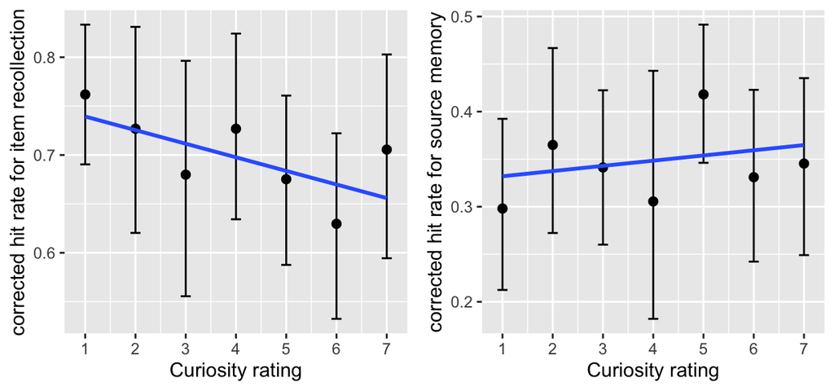

### 1.2.1 Item recollection

#### 1.2.1.1 Correlation with the average score

```
##                  Model df       AIC       BIC   logLik   Test  L.Ratio
## baseline.rating      1  3 -58.90848 -49.91684 32.45424
## rating.intercept     2  4 -62.91877 -50.92993 35.45939 1 vs 2 6.010295
## rating.slope         3  6 -58.92295 -40.93967 35.46147 2 vs 3 0.004173
## tr.intercept         4  7 -59.12057 -38.14009 36.56029 3 vs 4 2.197627
## tr.slope             5  8 -57.14769 -33.16999 36.57384 4 vs 5 0.027115
##                  p-value
## baseline.rating
## rating.intercept  0.0142
## rating.slope      0.9979
## tr.intercept      0.1382
## tr.slope          0.8692
```

#### 1.2.1.2 Correlation with the PC score

```
##                  Model df       AIC       BIC   logLik   Test  L.Ratio
## baseline.rating      1  3 -58.90848 -49.91684 32.45424
## rating.intercept     2  4 -62.91877 -50.92993 35.45939 1 vs 2 6.010295
## rating.slope         3  6 -58.92295 -40.93967 35.46147 2 vs 3 0.004173
## PC.intercept         4  7 -59.91886 -38.93838 36.95943 3 vs 4 2.995914
## PC.slope             5  8 -57.99281 -34.01511 36.99641 4 vs 5 0.073949
##                  p-value
## baseline.rating
## rating.intercept  0.0142
## rating.slope      0.9979
## PC.intercept      0.0835
## PC.slope          0.7857
```

```
##                   Value   Std.Error  DF   t-value      p-value
## (Intercept)  1.13948430 0.223295451 120  5.103034 1.268071e-06
## CurRating   -0.01644038 0.006724467 120 -2.444859 1.594364e-02
## PC          -0.13756176 0.078320181  25 -1.756402 9.126444e-02
```

#### 1.2.1.3 Correlation with the EC score

```
##                  Model df       AIC       BIC   logLik   Test  L.Ratio
## baseline.rating      1  3 -58.90848 -49.91684 32.45424
## rating.intercept     2  4 -62.91877 -50.92993 35.45939 1 vs 2 6.010295
## rating.slope         3  6 -58.92295 -40.93967 35.46147 2 vs 3 0.004173
## EC.intercept         4  7 -57.85638 -36.87590 35.92819 3 vs 4 0.933436
## EC.slope             5  8 -55.85793 -31.88023 35.92896 4 vs 5 0.001542
##                  p-value
## baseline.rating
## rating.intercept  0.0142
## rating.slope      0.9979
## EC.intercept      0.3340
## EC.slope          0.9687
```

### 1.2.2 Source memory

#### 1.2.2.1 Correlation with the average score

```
##                  Model df       AIC        BIC   logLik   Test   L.Ratio
## baseline.rating      1  3 -38.02375 -29.032110 22.01187
## rating.intercept     2  4 -36.17609 -24.187240 22.08805 1 vs 2 0.1523427
## rating.slope         3  6 -33.04241 -15.059134 22.52120 2 vs 3 0.8663187
## tr.intercept         4  7 -33.32973 -12.349248 23.66487 3 vs 4 2.2873261
## tr.slope             5  8 -31.34717  -7.369469 23.67358 4 vs 5 0.0174335
##                  p-value
## baseline.rating
## rating.intercept  0.6963
## rating.slope      0.6485
## tr.intercept      0.1304
## tr.slope          0.8950
```

#### 1.2.2.2 Correlation with the PC score

```
##                  Model df       AIC        BIC   logLik   Test  L.Ratio
## baseline.rating      1  3 -38.02375 -29.032110 22.01187
## rating.intercept     2  4 -36.17609 -24.187240 22.08805 1 vs 2 0.152343
## rating.slope         3  6 -33.04241 -15.059134 22.52120 2 vs 3 0.866319
## PC.intercept         4  7 -34.90812 -13.927632 24.45406 3 vs 4 3.865710
## PC.slope             5  8 -32.91773  -8.940035 24.45887 4 vs 5 0.009615
##                  p-value
## baseline.rating
## rating.intercept  0.6963
## rating.slope      0.6485
## PC.intercept      0.0493
## PC.slope          0.9219
```

```
##                    Value   Std.Error  DF    t-value      p-value
## (Intercept)  0.636145502 0.154778090 120  4.1100488 7.268976e-05
## CurRating    0.003571481 0.008190062 120  0.4360749 6.635659e-01
## PC          -0.109418093 0.054211044  25 -2.0183727 5.440265e-02
```

#### 1.2.2.3 Correlation with the EC score

```
##                  Model df       AIC       BIC   logLik   Test   L.Ratio
## baseline.rating      1  3 -38.02375 -29.03211 22.01187
## rating.intercept     2  4 -36.17609 -24.18724 22.08805 1 vs 2 0.1523427
## rating.slope         3  6 -33.04241 -15.05913 22.52120 2 vs 3 0.8663187
## EC.intercept         4  7 -31.74114 -10.76065 22.87057 3 vs 4 0.6987324
## EC.slope             5  8 -29.76281  -5.78511 22.88140 4 vs 5 0.0216677
##                  p-value
## baseline.rating
## rating.intercept  0.6963
## rating.slope      0.6485
## EC.intercept      0.4032
## EC.slope          0.8830
```

# 2 Relationship between trait score and curiosity ratings

## 2.1 Across all the rooms

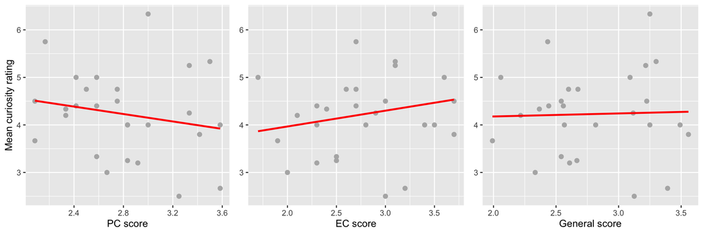

```r
cor.test(trait.ratings$meanCurRating, trait.ratings$PC, method = "pearson")
```

```
##
##  Pearson's product-moment correlation
##
## data:  trait.ratings$meanCurRating and trait.ratings$PC
## t = -0.99893, df = 25, p-value = 0.3274
## alternative hypothesis: true correlation is not equal to 0
## 95 percent confidence interval:
##  -0.5360220  0.1989076
## sample estimates:
##        cor
## -0.1959151
```

```r
cor.test(trait.ratings$meanCurRating, trait.ratings$EC, method = "pearson")
```

```
##
##  Pearson's product-moment correlation
##
## data:  trait.ratings$meanCurRating and trait.ratings$EC
## t = 1.0607, df = 25, p-value = 0.2989
## alternative hypothesis: true correlation is not equal to 0
## 95 percent confidence interval:
##  -0.1872506  0.5445955
## sample estimates:
##       cor
## 0.2075308
```

```r
cor.test(trait.ratings$meanCurRating, trait.ratings$GN, method = "pearson")
```

```
##
##  Pearson's product-moment correlation
##
## data:  trait.ratings$meanCurRating and trait.ratings$GN
## t = 0.15776, df = 25, p-value = 0.8759
## alternative hypothesis: true correlation is not equal to 0
## 95 percent confidence interval:
##  -0.3527037  0.4066774
## sample estimates:
##        cor
## 0.03153727
```

## 2.2 Only for the *novel* rooms

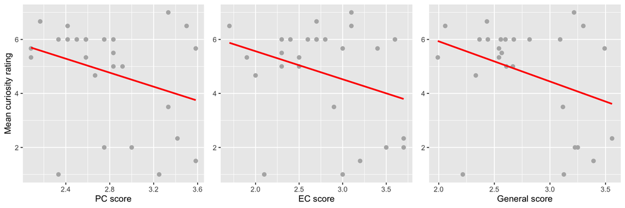

```
##
##  Pearson's product-moment correlation
##
## data:  trait.ratings.novel$meanCurRating and trait.ratings.novel$PC
## t = -1.6295, df = 24, p-value = 0.1163
## alternative hypothesis: true correlation is not equal to 0
## 95 percent confidence interval:
##  -0.62638644  0.08173179
## sample estimates:
##        cor
## -0.3156121
```

```
##
##  Pearson's product-moment correlation
##
## data:  trait.ratings.novel$meanCurRating and trait.ratings.novel$EC
## t = -1.575, df = 24, p-value = 0.1283
## alternative hypothesis: true correlation is not equal to 0
## 95 percent confidence interval:
##  -0.61992279  0.09221905
## sample estimates:
##        cor
## -0.3060659
```

```
##
##  Pearson's product-moment correlation
##
## data:  trait.ratings.novel$meanCurRating and trait.ratings.novel$GN
## t = -1.8439, df = 24, p-value = 0.07758
## alternative hypothesis: true correlation is not equal to 0
## 95 percent confidence interval:
##  -0.65081036  0.04063588
## sample estimates:
##        cor
## -0.3522608
```

# 3 Relationship between trait score and memory performance

Here *memory performance* refers to the average corrected hit rate for “seen” response for items and average corrected hit rate for source memory.

## 3.1 Outside

### 3.1.1 Item recollection

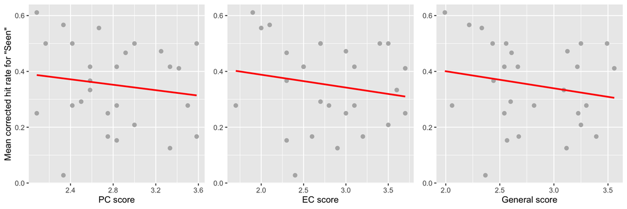

```
##
##  Pearson's product-moment correlation
##
## data:  outside.hit.rate.trait$meanSAcc and outside.hit.rate.trait$PC
## t = -0.72697, df = 25, p-value = 0.474
## alternative hypothesis: true correlation is not equal to 0
## 95 percent confidence interval:
##  -0.4967358  0.2497899
## sample estimates:
##        cor
## -0.1438819
```

```
##
##  Pearson's product-moment correlation
##
## data:  outside.hit.rate.trait$meanSAcc and outside.hit.rate.trait$EC
## t = -0.85974, df = 25, p-value = 0.3981
## alternative hypothesis: true correlation is not equal to 0
## 95 percent confidence interval:
##  -0.5162309  0.2250453
## sample estimates:
##       cor
## -0.169461
```

```
##
##  Pearson's product-moment correlation
##
## data:  outside.hit.rate.trait$meanSAcc and outside.hit.rate.trait$GN
## t = -0.91071, df = 25, p-value = 0.3711
## alternative hypothesis: true correlation is not equal to 0
## 95 percent confidence interval:
##  -0.5235550  0.2154953
## sample estimates:
##       cor
## -0.179193
```

### 3.1.2 Source memory

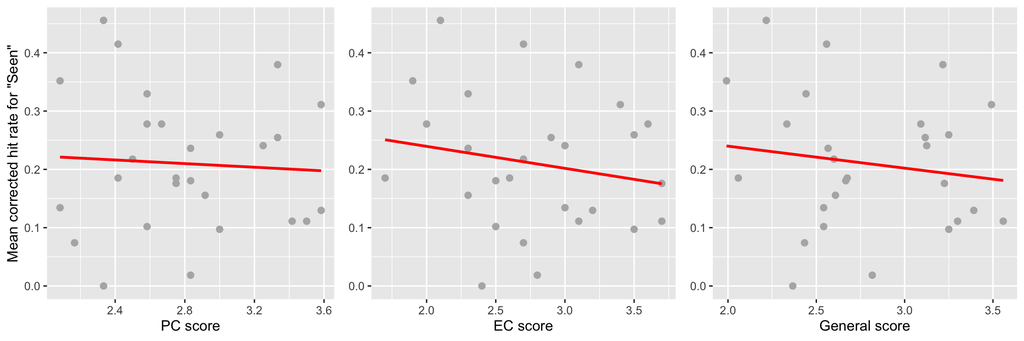

```
##
##  Pearson's product-moment correlation
##
## data:  outside.hit.rate.trait$meanSrcAcc and outside.hit.rate.trait$PC
## t = -0.30494, df = 25, p-value = 0.7629
## alternative hypothesis: true correlation is not equal to 0
## 95 percent confidence interval:
##  -0.4309209  0.3266959
## sample estimates:
##         cor
## -0.06087569
```

```
##
##  Pearson's product-moment correlation
##
## data:  outside.hit.rate.trait$meanSrcAcc and outside.hit.rate.trait$EC
## t = -0.93251, df = 25, p-value = 0.36
## alternative hypothesis: true correlation is not equal to 0
## 95 percent confidence interval:
##  -0.5266615  0.2114015
## sample estimates:
##        cor
## -0.1833412
```

```
##
##  Pearson's product-moment correlation
##
## data:  outside.hit.rate.trait$meanSrcAcc and outside.hit.rate.trait$GN
## t = -0.73792, df = 25, p-value = 0.4674
## alternative hypothesis: true correlation is not equal to 0
## 95 percent confidence interval:
##  -0.4983661  0.2477573
## sample estimates:
##       cor
## -0.146003
```

## 3.2 Inside

### 3.2.1 Item recollection

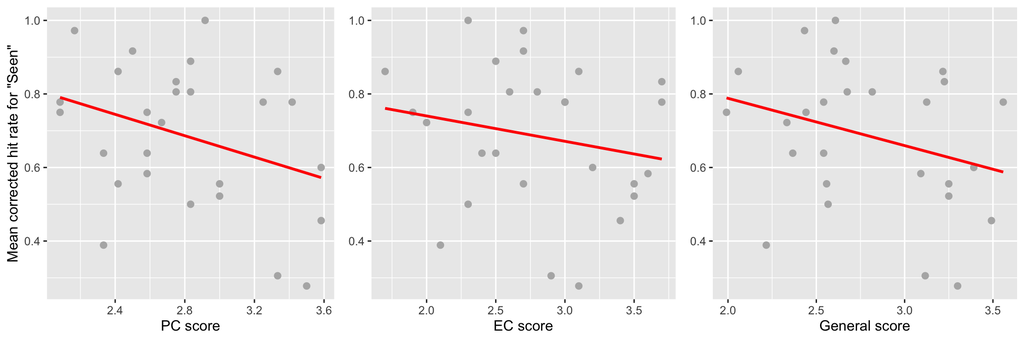

```
##
##  Pearson's product-moment correlation
##
## data:  inside.hit.rate.trait$meanSAcc and inside.hit.rate.trait$PC
## t = -1.797, df = 25, p-value = 0.08442
## alternative hypothesis: true correlation is not equal to 0
## 95 percent confidence interval:
##  -0.63643884  0.04795005
## sample estimates:
##       cor
## -0.338227
```

```
##
##  Pearson's product-moment correlation
##
## data:  inside.hit.rate.trait$meanSAcc and inside.hit.rate.trait$EC
## t = -1.0196, df = 25, p-value = 0.3177
## alternative hypothesis: true correlation is not equal to 0
## 95 percent confidence interval:
##  -0.5389063  0.1950091
## sample estimates:
##        cor
## -0.1998122
```

```
##
##  Pearson's product-moment correlation
##
## data:  inside.hit.rate.trait$meanSAcc and inside.hit.rate.trait$GN
## t = -1.5518, df = 25, p-value = 0.1333
## alternative hypothesis: true correlation is not equal to 0
## 95 percent confidence interval:
##  -0.60794762  0.09421249
## sample estimates:
##        cor
## -0.2964137
```

### 3.2.2 Source memory

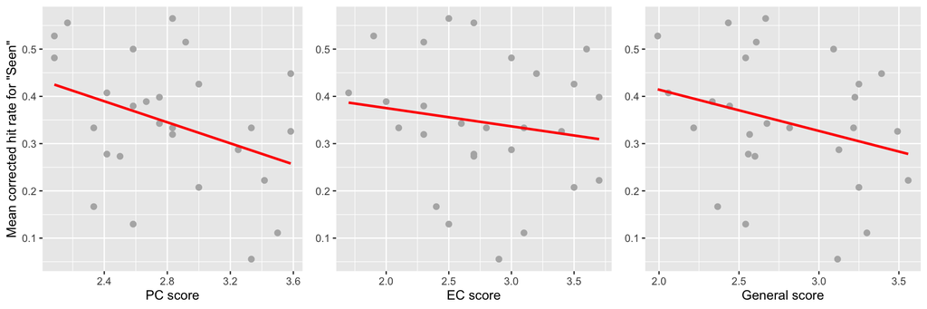

```
##
##  Pearson's product-moment correlation
##
## data:  inside.hit.rate.trait$meanSrcAcc and inside.hit.rate.trait$PC
## t = -1.9843, df = 25, p-value = 0.05831
## alternative hypothesis: true correlation is not equal to 0
## 95 percent confidence interval:
##  -0.65681227  0.01296467
## sample estimates:
##        cor
## -0.3688666
```

```
##
##  Pearson's product-moment correlation
##
## data:  inside.hit.rate.trait$meanSrcAcc and inside.hit.rate.trait$EC
## t = -0.80644, df = 25, p-value = 0.4276
## alternative hypothesis: true correlation is not equal to 0
## 95 percent confidence interval:
##  -0.5084768  0.2350032
## sample estimates:
##        cor
## -0.1592308
```

```
##
##  Pearson's product-moment correlation
##
## data:  inside.hit.rate.trait$meanSrcAcc and inside.hit.rate.trait$GN
## t = -1.4945, df = 25, p-value = 0.1476
## alternative hypothesis: true correlation is not equal to 0
## 95 percent confidence interval:
##  -0.6009847  0.1050755
## sample estimates:
##        cor
## -0.2863734
```

# 4 Relationship between trait score and memory performance within *Novel* rooms

Here *memory performance* refers to the average corrected hit rate for “seen” response for items and average corrected hit rate for source memory.

## 4.1 Outside

### 4.1.1 Item recollection

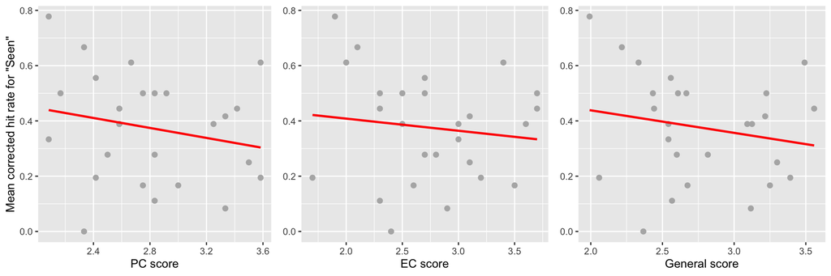

```
##
##  Pearson's product-moment correlation
##
## data:  outside.hit.rate.trait.novel$meanSAcc and outside.hit.rate.trait.novel$PC
## t = -1.0727, df = 24, p-value = 0.2941
## alternative hypothesis: true correlation is not equal to 0
## 95 percent confidence interval:
##  -0.5552474  0.1891212
## sample estimates:
##        cor
## -0.2139003
```

```
##
##  Pearson's product-moment correlation
##
## data:  outside.hit.rate.trait.novel$meanSAcc and outside.hit.rate.trait.novel$EC
## t = -0.62239, df = 24, p-value = 0.5396
## alternative hypothesis: true correlation is not equal to 0
## 95 percent confidence interval:
##  -0.4894881  0.2747316
## sample estimates:
##        cor
## -0.1260325
```

```
##
##  Pearson's product-moment correlation
##
## data:  outside.hit.rate.trait.novel$meanSAcc and outside.hit.rate.trait.novel$GN
## t = -0.93863, df = 24, p-value = 0.3573
## alternative hypothesis: true correlation is not equal to 0
## 95 percent confidence interval:
##  -0.5364260  0.2148375
## sample estimates:
##        cor
## -0.1881738
```

### 4.1.2 Source memory

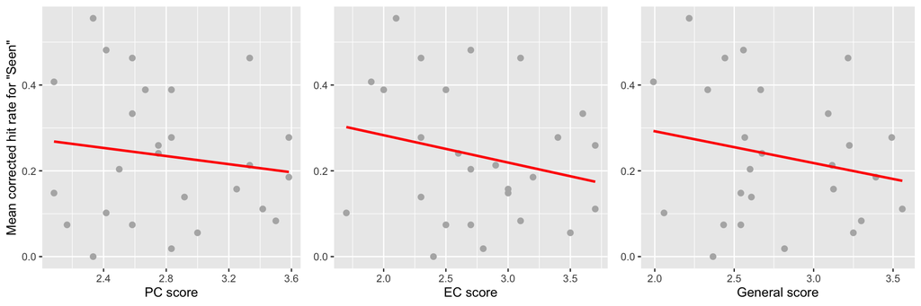

```
##
##  Pearson's product-moment correlation
##
## data:  outside.hit.rate.trait.novel$meanSrcAcc and outside.hit.rate.trait.novel$PC
## t = -0.68173, df = 24, p-value = 0.5019
## alternative hypothesis: true correlation is not equal to 0
## 95 percent confidence interval:
##  -0.4985632  0.2635962
## sample estimates:
##        cor
## -0.1378287
```

```
##
##  Pearson's product-moment correlation
##
## data:  outside.hit.rate.trait.novel$meanSrcAcc and outside.hit.rate.trait.novel$EC
## t = -1.1302, df = 24, p-value = 0.2696
## alternative hypothesis: true correlation is not equal to 0
## 95 percent confidence interval:
##  -0.5631164  0.1780581
## sample estimates:
##        cor
## -0.2247985
```

```
##
##  Pearson's product-moment correlation
##
## data:  outside.hit.rate.trait.novel$meanSrcAcc and outside.hit.rate.trait.novel$GN
## t = -1.0546, df = 24, p-value = 0.3021
## alternative hypothesis: true correlation is not equal to 0
## 95 percent confidence interval:
##  -0.5527422  0.1926041
## sample estimates:
##        cor
## -0.2104485
```

## 4.2 Inside

### 4.2.1 Item recollection

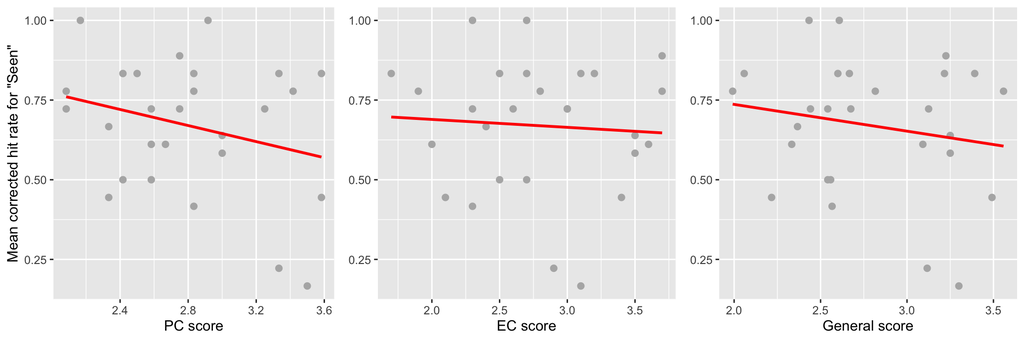

```
##
##  Pearson's product-moment correlation
##
## data:  inside.hit.rate.trait.novel$meanSAcc and inside.hit.rate.trait.novel$PC
## t = -1.4251, df = 25, p-value = 0.1665
## alternative hypothesis: true correlation is not equal to 0
## 95 percent confidence interval:
##  -0.5924047  0.1182334
## sample estimates:
##        cor
## -0.2740958
```

```
##
##  Pearson's product-moment correlation
##
## data:  inside.hit.rate.trait.novel$meanSAcc and inside.hit.rate.trait.novel$EC
## t = -0.33702, df = 25, p-value = 0.7389
## alternative hypothesis: true correlation is not equal to 0
## 95 percent confidence interval:
##  -0.4361201  0.3209649
## sample estimates:
##         cor
## -0.06725188
```

```
##
##  Pearson's product-moment correlation
##
## data:  inside.hit.rate.trait.novel$meanSAcc and inside.hit.rate.trait.novel$GN
## t = -0.91858, df = 25, p-value = 0.3671
## alternative hypothesis: true correlation is not equal to 0
## 95 percent confidence interval:
##  -0.5246782  0.2140181
## sample estimates:
##        cor
## -0.1806914
```

### 4.2.2 Source memory

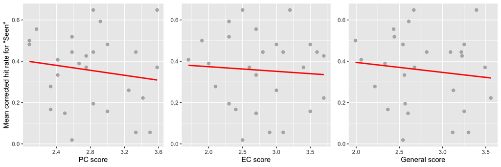

```
##
##  Pearson's product-moment correlation
##
## data:  inside.hit.rate.trait.novel$meanSrcAcc and inside.hit.rate.trait.novel$PC
## t = -0.76198, df = 25, p-value = 0.4532
## alternative hypothesis: true correlation is not equal to 0
## 95 percent confidence interval:
##  -0.5019346  0.2432852
## sample estimates:
##        cor
## -0.1506573
```

```
##
##  Pearson's product-moment correlation
##
## data:  inside.hit.rate.trait.novel$meanSrcAcc and inside.hit.rate.trait.novel$EC
## t = -0.35251, df = 25, p-value = 0.7274
## alternative hypothesis: true correlation is not equal to 0
## 95 percent confidence interval:
##  -0.4386198  0.3181896
## sample estimates:
##         cor
## -0.07032824
```

```
##
##  Pearson's product-moment correlation
##
## data:  inside.hit.rate.trait.novel$meanSrcAcc and inside.hit.rate.trait.novel$GN
## t = -0.60586, df = 25, p-value = 0.5501
## alternative hypothesis: true correlation is not equal to 0
## 95 percent confidence interval:
##  -0.4784354  0.2721632
## sample estimates:
##       cor
## -0.120292
```

# 5 Relationship between trait score and curiosity ratings between *Familiar* and *Novel* rooms

Here *performance difference* refers to difference in item recollection and source memory between the *novel* and *familiar* rooms (*novel* - *familiar*).

## 5.1 See whether the curiosity ratings are significantly different between *novel* and *familiar* rooms

The average curiosity rating for the *novel* rooms is 4.78 (SD = $\pm$ 1.9).

The average curiosity rating for the *familiar* rooms is 3.08 (SD = $\pm$ 1.71).

```
##
##  One Sample t-test
##
## data:  outside.hit.rate.trait.diff$diffRating
## t = 2.827, df = 25, p-value = 0.009112
## alternative hypothesis: true mean is not equal to 0
## 95 percent confidence interval:
##  0.4942367 3.1467889
## sample estimates:
## mean of x
##  1.820513
```

## 5.2 See whether the difference in curiosity ratings are significantly correlated with trait scores

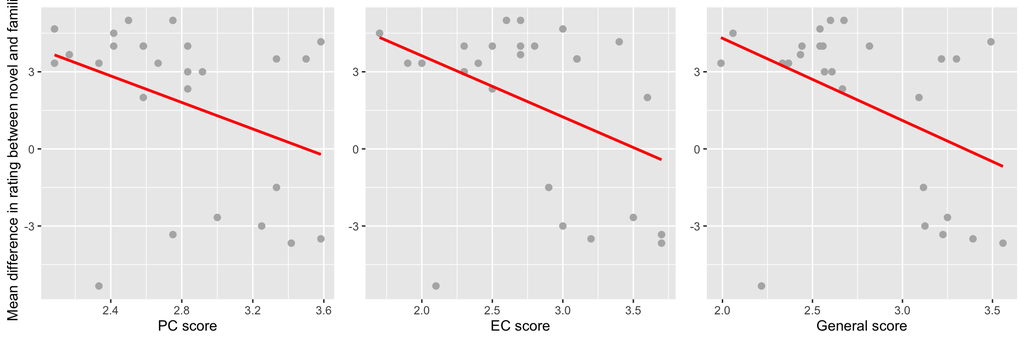

```
##
##  Pearson's product-moment correlation
##
## data:  outside.hit.rate.trait.diff$diffRating and outside.hit.rate.trait.diff$PC
## t = -1.91, df = 24, p-value = 0.06816
## alternative hypothesis: true correlation is not equal to 0
## 95 percent confidence interval:
##  -0.65800966  0.02805877
## sample estimates:
##        cor
## -0.3632411
```

```
##
##  Pearson's product-moment correlation
##
## data:  outside.hit.rate.trait.diff$diffRating and outside.hit.rate.trait.diff$EC
## t = -2.1686, df = 24, p-value = 0.04025
## alternative hypothesis: true correlation is not equal to 0
## 95 percent confidence interval:
##  -0.68476032 -0.02065825
## sample estimates:
##        cor
## -0.4047712
```

```
##
##  Pearson's product-moment correlation
##
## data:  outside.hit.rate.trait.diff$diffRating and outside.hit.rate.trait.diff$GN
## t = -2.3872, df = 24, p-value = 0.02521
## alternative hypothesis: true correlation is not equal to 0
## 95 percent confidence interval:
##  -0.70566123 -0.06105088
## sample estimates:
##        cor
## -0.4380439
```

### 5.2.1 Looking at the trait-rating correlation separately for the *novel* and *familiar* rooms

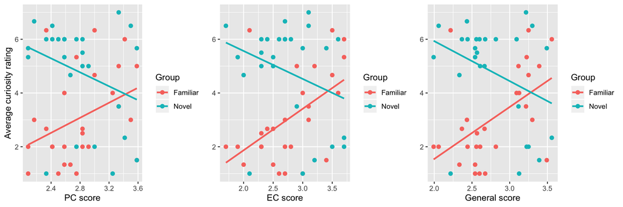

# 6 Relationship between trait score and performance differences between *Familiar* and *Novel* rooms

Here *performance difference* refers to difference in item recollection and source memory between the *novel* and *familiar* rooms (*novel* - *familiar*).

## 6.1 Outside

### 6.1.1 Item recollection

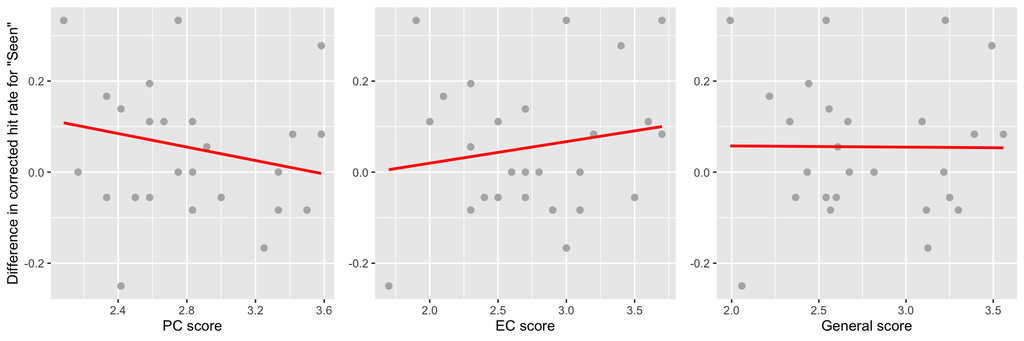

### 6.1.2 Source memory

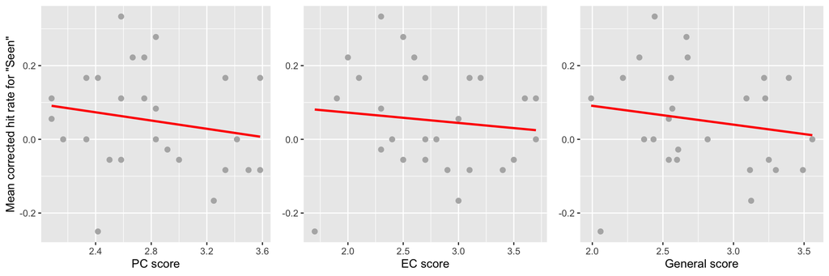

```
##
##  Pearson's product-moment correlation
##
## data:  outside.hit.rate.trait.diff$diffSrcAcc and outside.hit.rate.trait.diff$PC
## t = -0.9117, df = 24, p-value = 0.371
## alternative hypothesis: true correlation is not equal to 0
## 95 percent confidence interval:
##  -0.5325673  0.2199841
## sample estimates:
##        cor
## -0.1829579
```

```
##
##  Pearson's product-moment correlation
##
## data:  outside.hit.rate.trait.diff$diffSrcAcc and outside.hit.rate.trait.diff$EC
## t = -0.5466, df = 24, p-value = 0.5897
## alternative hypothesis: true correlation is not equal to 0
## 95 percent confidence interval:
##  -0.4777195  0.2888730
## sample estimates:
##        cor
## -0.1108867
```

```
##
##  Pearson's product-moment correlation
##
## data:  outside.hit.rate.trait.diff$diffSrcAcc and outside.hit.rate.trait.diff$GN
## t = -0.80869, df = 24, p-value = 0.4266
## alternative hypothesis: true correlation is not equal to 0
## 95 percent confidence interval:
##  -0.5175694  0.2395978
## sample estimates:
##        cor
## -0.1628698
```

## 6.2 Inside

### 6.2.1 Item recollection

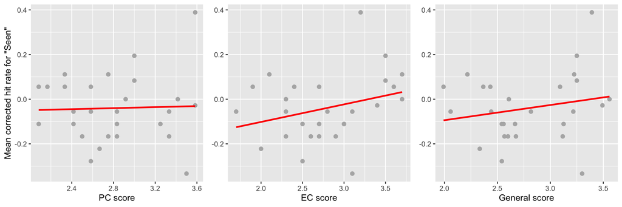

```
##
##  Pearson's product-moment correlation
##
## data:  inside.hit.rate.trait.diff$diffSAcc and inside.hit.rate.trait.diff$PC
## t = 0.1711, df = 25, p-value = 0.8655
## alternative hypothesis: true correlation is not equal to 0
## 95 percent confidence interval:
##  -0.3503675  0.4088997
## sample estimates:
##        cor
## 0.03419999
```

```
##
##  Pearson's product-moment correlation
##
## data:  inside.hit.rate.trait.diff$diffSAcc and inside.hit.rate.trait.diff$EC
## t = 1.5336, df = 25, p-value = 0.1377
## alternative hypothesis: true correlation is not equal to 0
## 95 percent confidence interval:
##  -0.0976614  0.6057486
## sample estimates:
##       cor
## 0.2932353
```

```
##
##  Pearson's product-moment correlation
##
## data:  inside.hit.rate.trait.diff$diffSAcc and inside.hit.rate.trait.diff$GN
## t = 1.0292, df = 25, p-value = 0.3132
## alternative hypothesis: true correlation is not equal to 0
## 95 percent confidence interval:
##  -0.1931961  0.5402417
## sample estimates:
##       cor
## 0.2016203
```

### 6.2.2 Source memory

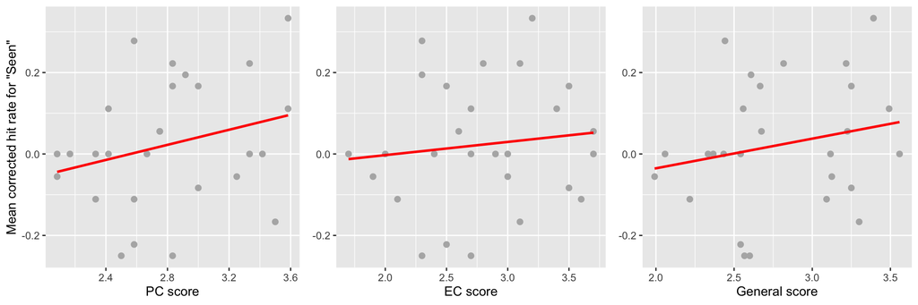

```
##
##  Pearson's product-moment correlation
##
## data:  inside.hit.rate.trait.diff$diffSrcAcc and inside.hit.rate.trait.diff$PC
## t = 1.3966, df = 25, p-value = 0.1748
## alternative hypothesis: true correlation is not equal to 0
## 95 percent confidence interval:
##  -0.1236398  0.5888320
## sample estimates:
##       cor
## 0.2690138
```

```
##
##  Pearson's product-moment correlation
##
## data:  inside.hit.rate.trait.diff$diffSrcAcc and inside.hit.rate.trait.diff$EC
## t = 0.59016, df = 25, p-value = 0.5604
## alternative hypothesis: true correlation is not equal to 0
## 95 percent confidence interval:
##  -0.2750482  0.4760272
## sample estimates:
##       cor
## 0.1172176
```

```
##
##  Pearson's product-moment correlation
##
## data:  inside.hit.rate.trait.diff$diffSrcAcc and inside.hit.rate.trait.diff$GN
## t = 1.0715, df = 25, p-value = 0.2942
## alternative hypothesis: true correlation is not equal to 0
## 95 percent confidence interval:
##  -0.1852255  0.5460694
## sample estimates:
##       cor
## 0.2095374
```